# Environmental Bytes for a Better Earth

One of my favourite hobbies is learning new things, as well as helping others to do the same. On this page you can find my blogs documenting the wide range of skills I have learnt as an Environmental Data Analyst, with everything from low level R coding concepts, all the way to fully fledge data analysis pipelines, dashboards built with Tableau, and examples of SQL and database management.

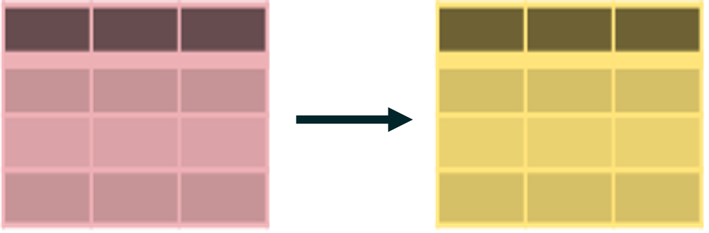

### An Opinionated Dataframe Cleaner

Naming your dataframe columns doesn’t have to be hard, does it? Here I demonstrate the benefits of implimenting an opionated dataframe cleaner to help keep your columns organised.

04 Jan, 2025

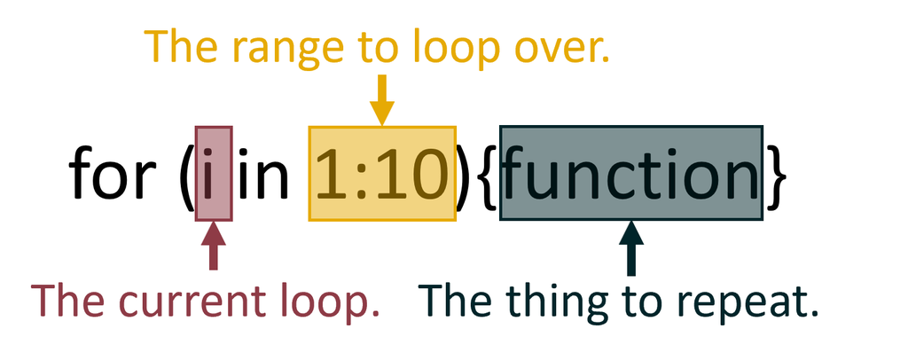

### Going Loopy for For Loops

Whats the point of for loops? Well for looping of course. In this post I break down how to write for loops in R, how you can easily understand them, and compelling reasons that you might want to learn them yourself!

04 Jan, 2025

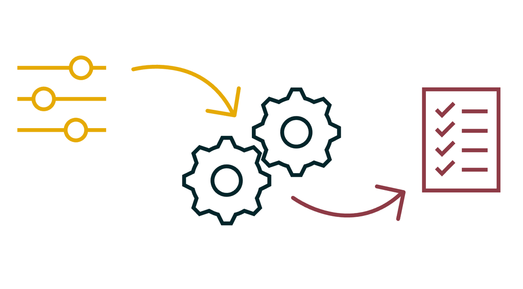

### Learning To Create Your Own Custom Functions

Having the ability to create functions is both a blessing and a curse. You are gifted with limitless potential, but absolutely limited power supply (AKA your brain). In this post I discuss how I learnt to make my own functions and the trials I faced along the way.

04 Jan, 2025

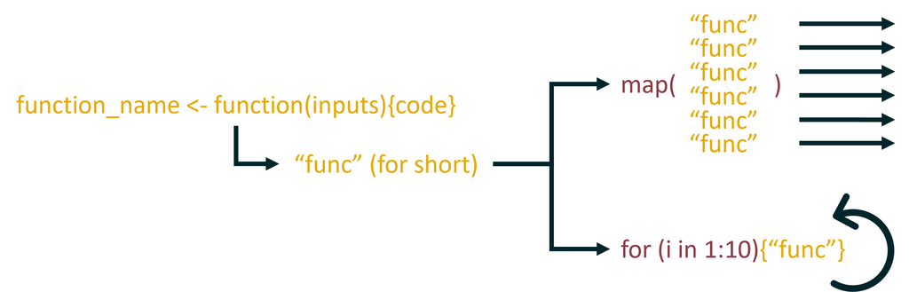

### An Epic Battle Between For Loops and Vectorised Functions

04 Jan, 2025

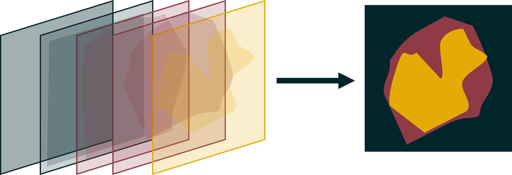

### Making Beautiful Maps in R

Creating maps using a programming language can be a painful process. The lack of a visual editor with realtime feedback, varying proportions between console and outputs, and complicated syntax to tie your brain in knots! In this blog I explore the R package ‘tmap’ and how it can be used to programmatically make beautiful, report ready maps, with as little stress as possible.

04 Jan, 2025

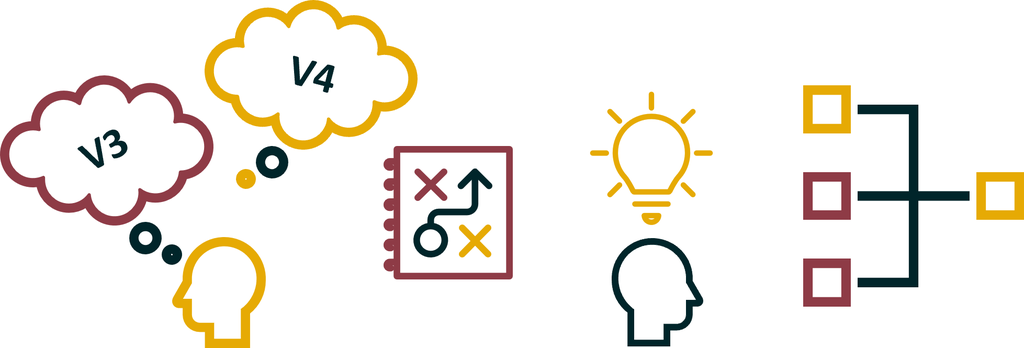

### Migrating to Version 4 of the tmap R Package

My favourite mapping package just released a major update! In this post I discuss the changes made as they relate to my work, and provide some tips and tricks I have learnt so far when migration from Version 3.0 to Version 4.0.

04 Jan, 2025